# Nạp chồng toán tử

Toán tử Python làm việc bằng các hàm được dựng sẵn, nhưng một toán tử có thể được sử dụng để thực hiện nhiều hoạt động khác nhau. Ví dụ với toán tử ' + ', bạn có thể cộng số học hai số với nhau, có thể kết hợp hai danh sách, hoặc nối hai chuỗi khác nhau lại…

Tính năng này trong Python gọi là nạp chồng toán tử, cho phép cùng một toán tử được sử dụng khác nhau tùy từng ngữ cảnh.

**Sử dụng nạp chồng toán tử với object của một lớp do người dùng khai báo**

```python
class Point:
    def __init__(self, x = 0, y = 0):
        self.x = x
        self.y = y
```

**Ta chạy chương trình và nhập vào các điểm:**

```python
p1 = Point(2,3)
p2 = Point(-1,2)
p1 + p2
```

```
---------------------------------------------------------------------------
TypeError                                 Traceback (most recent call last)
<ipython-input-2-382eb40812ed> in <module>
      1 p1 = Point(2,3)
      2 p2 = Point(-1,2)
----> 3 p1 + p2

TypeError: unsupported operand type(s) for +: 'Point' and 'Point'
```

Chương trình ngay lập tức báo lỗi TypeError vì Python không thể nhận hai đối tượng Point cùng lúc.

Để xử lý vấn đề này, ta sẽ sử dụng nạp chồng toán tử.

### Một số hàm đặc biệt

Hàm trong Class được bắt đầu với hai dấu gạch dưới liền nhau (__) là các hàm đặc biệt, mang các ý nghĩa đặc biệt.

Có rất nhiều hàm đặc biệt trong Python và một trong đó là hàm **init** (), hàm này được gọi bất cứ khi nào khởi tạo một đối tượng, một biến mới trong class.

Mục đích khi sử dụng các hàm đặc biệt này là giúp những hàm của chúng ta tương thích với các hàm được dựng sẵn trong Python.

```python
class Point:
     def __init__(self, x = 0, y = 0):
        self.x = x
        self.y = y
```

```python
p1 = Point(2,3)
print(p1)
```

```
<__main__.Point object at 0x000002173D5779D0>
```

```python
p1.x
```

```
2
```

```python
str(p1)
```

```
'<__main__.Point object at 0x000002173D5779D0>'
```

```python
format(p1)
```

```
'<__main__.Point object at 0x000002173D5779D0>'
```

Khi sử dụng str() và format(), Python thực hiện lệnh gọi p1.**str** () nên kết quả được trả về tương tự.

**Nạp chồng toán tử '+'**

Để nạp chồng toán tử ' + ', ta sẽ sử dụng hàm **add** () trong class. Ta có thể triển khai nhiều công việc bằng hàm này, ví dụ như cộng hai điểm tọa độ ở ví dụ bên trên.

```python
class Point:
     def __init__(self, x = 0, y = 0):
        self.x = x
        self.y = y

     def __str__(self):
        return "({0},{1})".format(self.x,self.y)

     def __add__(self,other):
        x = self.x + other.x
        y = self.y + other.y
        return Point(x,y)
```

```python
p1 = Point(2,3)
p2 = Point(-1,2)
print(p1 + p2)
```

```
(1,5)
```

Khi thực hiện *p1 + p2*, Python sẽ gọi ra *p1.**add** (p2)*

Tương tự như vậy, có thể nạp chồng nhiều toán tử khác. Một số hàm đặc biệt dùng cho nạp chồng toán tử trong bảng dưới đây:

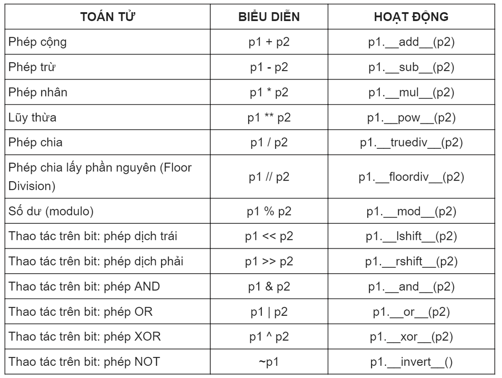

**Nạp chồng toán tử so sánh:**

Python không chỉ giới hạn được phép nạp chồng các toán tử toán học, mà còn cho phép người dùng nạp chồng toán tử so sánh.

Có nhiều toán tử so sánh được hỗ trợ bởi Python, ví dụ như: <, >, <=, >=, ==,...

Sử dụng nạp chồng toán tử này khi muốn so sánh các đối tượng trong lớp với nhau.

Ví dụ muốn so sánh các điểm trong class Point, hãy so sánh độ lớn của các điểm này bắt đầu từ gốc tọa độ, thực hiện như sau:

```python
class Point:
     def __init__(self, x = 0, y = 0):
        self.x = x
        self.y = y

     def __str__(self):
        return "({0},{1})".format(self.x,self.y)

     def __lt__(self,other):
        self_mag = (self.x ** 2) + (self.y ** 2)
        other_mag = (other.x ** 2) + (other.y ** 2)
        return self_mag < other_mag
```

Ta chạy chương trình và nhập vào các điểm và toán tử dùng để só sánh:

```python
Point(1,1) < Point(-2,-3)
```

```
True
```

```python
Point(1,1) < Point(0.5,-0.2)
```

```
False
```

```python
Point(1,1) < Point(1,1)
```

```
False
```

Có thể nạp chồng nhiều toán tử so sánh khác. Một số hàm đặc biệt dùng cho nạp chồng toán tử so sánh:

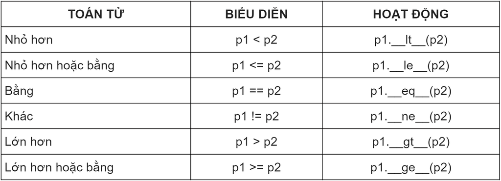